# Modelling workshop: Session 1

## Session 1

**Session 1** contains an introduction to **R** and **RStudio**, **data types** and **basic data manipulation** in R, with a brief introduction to **plotting** in base R.

### Session 1a - Introduction to R and RStudio

#### R

**R** is a programming language used for statistical computing and graphics. R is widely used by statisticians, data analysts, and researchers for data analyses and visualization. It was first developed by Ross Ihaka and Robert Gentleman at the University of Auckland, New Zealand in 1993, which I mention as I live in New Zealand.

R is free to use and, if you know what you are doing, you can contribute to it. There are currently nearly 20,000 **packages** that people have written to do specific tasks. You can see how many there are here: https://cran.r-project.org/web/packages/

#### RStudio

**RStudio** is an integrated development environment (IDE) for R that provides a more user-friendly interface for working with R. RStudio is a very helpful tool that simplifies the process of writing R code and analyzing data. It includes features such as code highlighting and debugging, and helps with visualization of the different parts of R.

##### Donwloading and installing R and RStudio

The first step is downloading and installing the software. You can download R from https://www.r-project.org/ and RStudio *and* R from https://posit.co/download/rstudio-desktop/

Once installed, you should now be able to open RStudio and see a screen like this:

[figure not shown]

RStudio

Spend a bit of time familiarizing yourselves with this screen and we will talk through this later.

##### Downloading and installing JAGS

Later in Session 7 we will use another piece of software, JAGS. You can download and install that from here: https://sourceforge.net/projects/mcmc-jags/files/

### Beginning to code

We will start by opening RStudio and begin with some of the most basic things about R.

First, let’s open an **R script** using two methods:

`Ctrl + Shift + N’

Then

File > New file > R Script

An R Script is simply a text file containing almost the same commands that you would enter on the *command line* of R.

##### Basic R functions

Here are some of the most basic R functions.

The **print()** function is used to display the value of an object or variable on the console. For example, in the newly opened R Script type the below R code and then *click on*:

**Run**

and then use:

`Control + Enter’

```r
print("Hello, world!")
```

```
## [1] "Hello, world!"
```

Now type $#$ and write anything you like after this:

```r
# test script
```

The $#$ sign and it is typically used for two purposes; 1) making notes and 2) commenting out lines of code in scripts. You will see this used throughout this workshop.

Now press

File > Save

and then use:

`Control + S’

To **save** the **script**.

We will *not* cover **shortcuts** any more, but you will learn them as you code more with time.

The **c()** function is used to create a *vector* of values. For example,

```r
c(1, 2, 3)
```

```
## [1] 1 2 3
```

creates a vector containing the values 1, 2, and 3.

The **length()** function is used to determine the length of a vector or the number of elements in an object. For example,

```r
length(c(1, 2, 3))
```

```
## [1] 3
```

returns the number 3 because there are three numbers. As does:

```r
length(c(3, 3, 3))
```

```
## [1] 3
```

because there are three numbers that happen to be 3. Similarly, so does:

```r
length(c(300, 30, 3))
```

```
## [1] 3
```

The **sum()** function is used to calculate the sum of a vector or a set of numbers. For example,

```r
sum(c(1, 2, 3))
```

```
## [1] 6
```

will return 6.

The **mean()** function is used to calculate the mean or average of a vector or a set of numbers. For example,

```r
mean(c(1, 2, 3))
```

```
## [1] 2
```

will return 2.

Note that some functions like **mean()** need certain conditions to be true before they can work. Let’s take a closer look at this example:

```r
n1 <- c(1,2,3,4,5)
n2 <- c(1,2,3,4,NA)
mean(n1)
```

```
## [1] 3
```

```r
mean(n2)
```

```
## [1] NA
```

The vector we made called *n2* includes an **NA**, which means *Not Available*, and so the function **mean()** cannot calculate the mean when a number does not exist (i.e. is an **NA**). We can easily resolve that here because **mean()** has a **logical** condition that we will learn more about later. Here it is **na.rm = FALSE** by default. We can change this default logical condition to **na.rm = TRUE** to get a different answer:

```r
n2 <- c(1,2,3,4,NA)
mean(n2, na.rm = TRUE)
```

```
## [1] 2.5
```

This is the mean of the four numbers.

The **sd()** function is used to calculate the standard deviation of a vector or a set of numbers. For example,

```r
sd(c(1, 2, 3, 4))
```

```
## [1] 1.290994
```

will return 1.290994.

The **var()** function is used to calculate the variance of a vector or a set of numbers. For example,

```r
var(c(1, 2, 3, 4))
```

```
## [1] 1.666667
```

will return 1.666667.

The **seq()** function is used to create a sequence of numbers. For example,

```r
seq(1, 5, by = 1)
```

```
## [1] 1 2 3 4 5
```

will create a vector containing the numbers 1, 2, 3, 4, and 5. Try:

```r
seq(1, 100, by = 10)
```

```
##  [1]  1 11 21 31 41 51 61 71 81 91
```

And the **rep()** function is used to repeat a value or a set of values a specified number of times. For example,

```r
rep(1, times = 3)
```

```
## [1] 1 1 1
```

will create a vector containing the values 1, 1, and 1.

The **plot()** function is used to create a plot of data. For example,

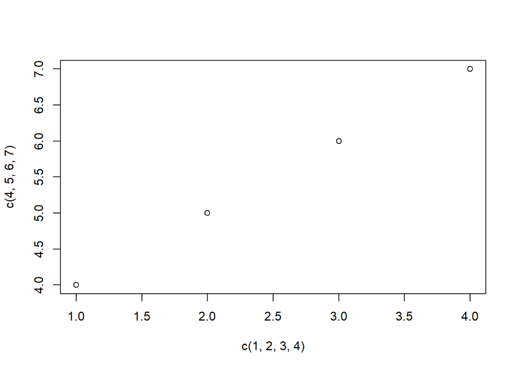

```r
plot(c(1, 2, 3, 4), c(4, 5, 6, 7))
```

will create a scatter plot of the points (1, 4), (2, 5), (3, 6) and (4, 7) with the first position the **x axis** values and the second position the **y axis** values.